# Analyse des Campagnes de Vaccination Animale

- Show All Code
- Hide All Code
- View Source

Gouvernorat de Sousse (2017-2020)

Author

Meddeb Acharf

Published

December 29, 2025

🔬 PROJET STATISTIQUE AVEC R

Analyse des Campagnes de Vaccination Animale  
Gouvernorat de Sousse (2017-2020)

```
📋 Informations du projet :
Auteur : Meddeb Acharf
Date : 2025-12-29
Source des données : Catalogue Open Data Tunisie (CRDA Sousse)
Logiciel : R version 4.3.1
```

📋 CONTEXTE DU PROJET

Les maladies animales contagieuses représentent une menace majeure pour :

- **L’élevage** et l’économie agricole
- **La santé publique** en Tunisie
- **L’économie nationale**

Ce projet analyse les données de vaccination animale du **Gouvernorat de Sousse** sur la période 2017-2020.

### 0.1 🦠 Maladies couvertes

```
Rage
```

```
Fièvre Aphteuse
```

```
Clavelée
```

```
Blue Tongue
```

🎯 OBJECTIFS DE L’ANALYSE

### 0.2 🎯 Objectif Général

Évaluer l’efficacité et la performance des campagnes de vaccination animale réalisées dans le Gouvernorat de Sousse sur la période **2017–2020**.

### 0.3 📊 Objectifs Spécifiques

1. Analyser l’évolution temporelle (2017-2020)
2. Mesurer les taux de couverture vaccinale
3. Évaluer l’écart objectifs vs réalisations
4. Classer les campagnes par efficacité
5. Identifier les points d’amélioration
6. Analyser statistiquement les différences
7. Modéliser par régression linéaire

### 0.4 📈 Classification de l’Efficacité

```
Excellente ≥ 90%
```

```
 Bonne 75-89%
```

```
Moyenne 50-74%
```

```
 Faible  50%
```

📊 DONNÉES UTILISÉES

```
 📅 Période
 4 ans
 2017 - 2020
```

```
📊 Observations
 44
 Enregistrements
```

```
 🔢 Variables
 7
 Colonnes
```

### 0.5 Structure des données

```
Variables disponibles dans le dataset :
```

```
1. année : Année de la campagne
```

```
2. Campagne_de_vaccination : Type de maladie
```

```
3. Espece_animale : Espèce ciblée
```

```
4. nombre_animaux_programmes : Objectifs
```

```
5. nombre_animaux_vaccines : Réalisations
```

```
6. taux_de_couverture : Performance
```

[output not shown]

🔧 SECTION 1 : PRÉPARATION DES DONNÉES

### 0.6 📚 Chargement des bibliothèques

**📝 Voir le code**

```r
# Chargement des bibliothèques essentielles
library(tidyverse)    # Manipulation et visualisation
library(ggthemes)     # Thèmes ggplot2
library(scales)       # Formatage des échelles
library(readxl)       # Lecture fichiers Excel
library(knitr)        # Rapport dynamique
library(kableExtra)   # Tables améliorées

# Configuration des thèmes
theme_set(theme_minimal(base_size = 12))

cat("✅ Bibliothèques chargées avec succès\n")
```

```
✅ Bibliothèques chargées avec succès
```

### 0.7 📥 Importation des données

**📝 Voir le code**

```r
# Importation des données
data_sousse <- read_excel("Data/campagnes-de-vaccination-2017-2020.xlsx")

# Message de confirmation
cat("✅ Données importées avec succès\n")
```

```
✅ Données importées avec succès
```

**📝 Voir le code**

```r
cat("📊 Dimensions :", nrow(data_sousse), "lignes ×", ncol(data_sousse), "colonnes\n")
```

```
📊 Dimensions : 44 lignes × 7 colonnes
```

**✅ Importation réussie :** Les données ont été chargées correctement depuis le fichier Excel.

🔍 SECTION 2 : EXPLORATION DES DONNÉES

### 0.8 🔎 Aperçu des données

| annee | Campagne_de_vaccination | Espece_animale | nombre_animaux_programmes | nombre_animaux_vaccines | nombre_de_proprietaires | taux_de_ couverture |
| --- | --- | --- | --- | --- | --- | --- |
| 2017 | La rage | chiens | 23750 | 23942 | 11880 | 100.00000 |
| 2017 | La rage | chats | 2000 | 711 | 450 | 35.55000 |
| 2017 | La rage | camelins | 425 | 360 | 69 | 84.70588 |
| 2017 | La rage | équins | 275 | 257 | 93 | 93.45455 |
| 2017 | La rage | bovins | 250 | 241 | 1 | 96.40000 |
| 2017 | Fièvre afteuse | bovins | 11000 | 10899 | 2324 | 99.08000 |
| 2017 | Fièvre afteuse | ovins | 280000 | 289453 | 9591 | 100.00000 |
| 2017 | Fièvre afteuse | caprins | 30000 | 29346 | 4138 | 97.82000 |
| 2017 | Clavelée | ovins | 280000 | 236810 | 7804 | 84.57000 |
| 2017 | Clavelée | camelins | 425 | 360 | 69 | 84.70000 |

### 0.9 🧹 Nettoyage et transformation

**📝 Voir le code**

```r
data_clean <- data_sousse %>%
  mutate(
    # Conversion en facteurs
    annee = as.factor(annee),
    Campagne_de_vaccination = as.factor(Campagne_de_vaccination),
    Espece_animale = as.factor(Espece_animale),

    # Nouvelles variables calculées
    taux_calcule = (nombre_animaux_vaccines / nombre_animaux_programmes) * 100,
    ecart = nombre_animaux_vaccines - nombre_animaux_programmes,
    ecart_pourcent = (ecart / nombre_animaux_programmes) * 100,

    # Catégorisation de l'efficacité
    efficacite = case_when(
      `taux_de_ couverture` >= 90 ~ "Excellente",
      `taux_de_ couverture` >= 75 ~ "Bonne",
      `taux_de_ couverture` >= 50 ~ "Moyenne",
      TRUE ~ "Faible"
    ),
    efficacite = factor(efficacite, levels = c("Excellente", "Bonne", "Moyenne", "Faible"))
  )

cat("✅ Dataset nettoyé et transformé\n")
```

```
✅ Dataset nettoyé et transformé
```

**📝 Voir le code**

```r
cat("📈 Variables créées : taux_calcule, ecart, ecart_pourcent, efficacite\n")
```

```
📈 Variables créées : taux_calcule, ecart, ecart_pourcent, efficacite
```

### 0.10 📊 Statistiques descriptives

**📝 Voir le code**

```r
summary_stats <- data_clean %>%
  summarise(
    Observations = n(),
    Campagnes = n_distinct(Campagne_de_vaccination),
    Espèces = n_distinct(Espece_animale),
    `Taux moyen` = round(mean(`taux_de_ couverture`, na.rm = TRUE), 1),
    `Animaux programmés (moyenne)` = round(mean(nombre_animaux_programmes)),
    `Animaux vaccinés (moyenne)` = round(mean(nombre_animaux_vaccines))
  )

kbl(summary_stats) %>%
  kable_styling(bootstrap_options = c("striped", "hover")) %>%
  column_spec(1, bold = TRUE)
```

| Observations | Campagnes | Espèces | Taux moyen | Animaux programmés (moyenne) | Animaux vaccinés (moyenne) |
| --- | --- | --- | --- | --- | --- |
| 44 | 4 | 7 | 79.4 | 80696 | 59606 |

📈 SECTION 3 : VISUALISATION DES DONNÉES

### 0.11 Graphique 1 : Évolution temporelle

**📝 Voir le code**

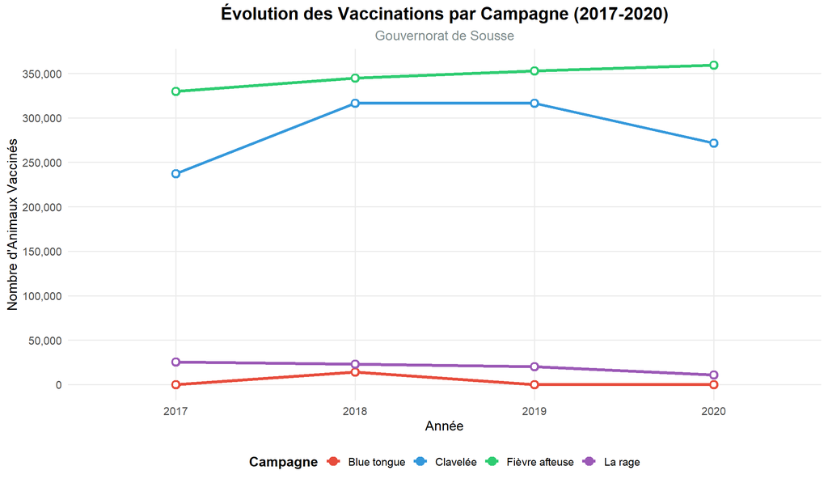

```r
# Graphique d'évolution temporelle
g1 <- data_clean %>%
  group_by(annee, Campagne_de_vaccination) %>%
  summarise(total_vaccines = sum(nombre_animaux_vaccines), .groups = 'drop') %>%
  ggplot(aes(x = annee, y = total_vaccines, color = Campagne_de_vaccination, group = Campagne_de_vaccination)) +
  geom_line(linewidth = 1.5) +
  geom_point(size = 4) +
  geom_point(size = 2, color = "white") +
  scale_y_continuous(labels = comma, breaks = scales::pretty_breaks(n = 10)) +
  scale_color_manual(values = c("#e74c3c", "#3498db", "#2ecc71", "#9b59b6")) +
  labs(
    title = "Évolution des Vaccinations par Campagne (2017-2020)",
    subtitle = "Gouvernorat de Sousse",
    x = "Année",
    y = "Nombre d'Animaux Vaccinés",
    color = "Campagne"
  ) +
  theme_minimal(base_size = 14) +
  theme(
    plot.title = element_text(face = "bold", size = 18, hjust = 0.5),
    plot.subtitle = element_text(hjust = 0.5, color = "#7f8c8d"),
    legend.position = "bottom",
    legend.title = element_text(face = "bold"),
    panel.grid.minor = element_blank()
  )

print(g1)
```

Figure 1 : Évolution du nombre d’animaux vaccinés par campagne

### 0.12 Graphique 2 : Performances par espèce

**📝 Voir le code**

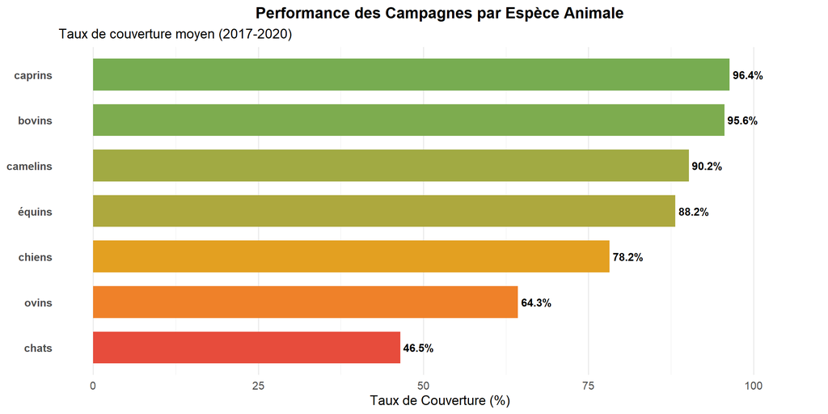

```r
# Taux de couverture par espèce
g2 <- data_clean %>%
  group_by(Espece_animale) %>%
  summarise(taux_moyen = mean(`taux_de_ couverture`, na.rm = TRUE)) %>%
  arrange(taux_moyen) %>%
  mutate(Espece_animale = fct_reorder(Espece_animale, taux_moyen)) %>%
  ggplot(aes(x = taux_moyen, y = Espece_animale, fill = taux_moyen)) +
  geom_col(width = 0.7) +
  geom_text(aes(label = sprintf("%.1f%%", taux_moyen)),
            hjust = -0.1,
            fontface = "bold",
            size = 4) +
  scale_fill_gradient2(
    low = "#e74c3c",
    mid = "#f39c12",
    high = "#27ae60",
    midpoint = 75,
    name = "Taux (%)"
  ) +
  labs(
    title = "Performance des Campagnes par Espèce Animale",
    subtitle = "Taux de couverture moyen (2017-2020)",
    x = "Taux de Couverture (%)",
    y = NULL
  ) +
  theme_minimal(base_size = 14) +
  theme(
    plot.title = element_text(face = "bold", size = 16, hjust = 0.5),
    axis.text.y = element_text(face = "bold"),
    legend.position = "none",
    panel.grid.major.y = element_blank()
  ) +
  xlim(0, 105)

print(g2)
```

Figure 2 : Taux de couverture moyen par espèce animale

### 0.13 Graphique 3 : Heatmap des performances

**📝 Voir le code**

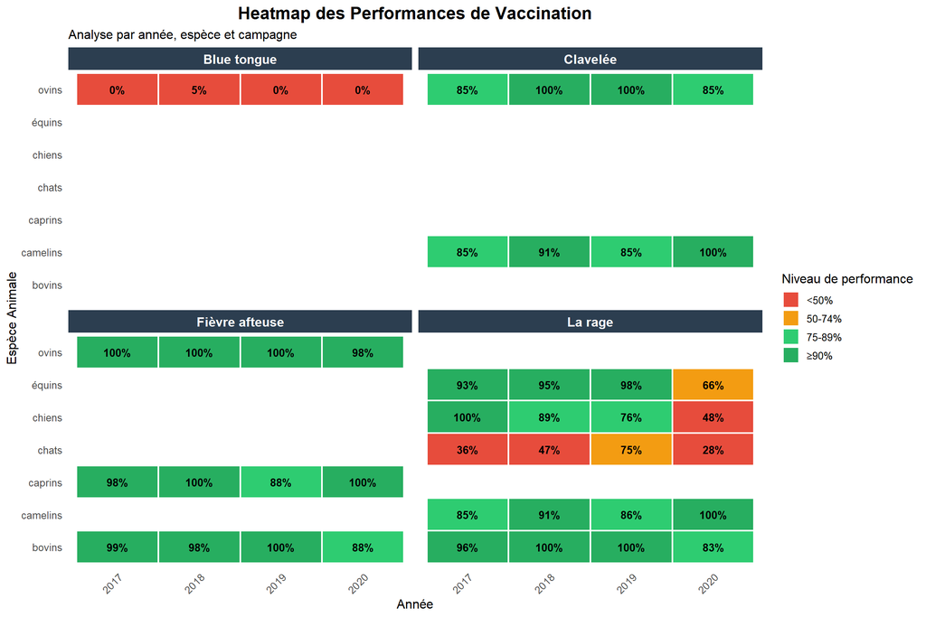

```r
# Heatmap des taux de couverture
g3 <- data_clean %>%
  mutate(
    taux_categorie = cut(`taux_de_ couverture`,
      breaks = c(0, 50, 75, 90, 100),
      labels = c("<50%", "50-74%", "75-89%", "≥90%"),
      include.lowest = TRUE)
  ) %>%
  ggplot(aes(x = annee, y = Espece_animale, fill = taux_categorie)) +
  geom_tile(color = "white", size = 0.8) +
  geom_text(aes(label = sprintf("%.0f%%", `taux_de_ couverture`)),
            color = "black",
            fontface = "bold",
            size = 3.5) +
  scale_fill_manual(
    values = c("<50%" = "#e74c3c",
               "50-74%" = "#f39c12",
               "75-89%" = "#2ecc71",
               "≥90%" = "#27ae60"),
    name = "Niveau de performance"
  ) +
  facet_wrap(~Campagne_de_vaccination, ncol = 2) +
  labs(
    title = "Heatmap des Performances de Vaccination",
    subtitle = "Analyse par année, espèce et campagne",
    x = "Année",
    y = "Espèce Animale"
  ) +
  theme_minimal(base_size = 12) +
  theme(
    plot.title = element_text(face = "bold", size = 16, hjust = 0.5),
    axis.text.x = element_text(angle = 45, hjust = 1),
    strip.text = element_text(face = "bold", size = 12, color = "white"),
    strip.background = element_rect(fill = "#2c3e50", color = NA),
    panel.grid = element_blank()
  )

print(g3)
```

Figure 3 : Visualisation matricielle des performances

📊 SECTION 4 : ANALYSES STATISTIQUES

### 0.14 🔬 Question 1 : Différences entre années ?

**📝 Voir le code**

```r
# Test ANOVA
anova_result <- aov(`taux_de_ couverture` ~ annee, data = data_clean)

# Résumé
cat("📊 ANALYSE DE VARIANCE (ANOVA)\n")
```

```
📊 ANALYSE DE VARIANCE (ANOVA)
```

**📝 Voir le code**

```r
cat("Hypothèse H0 : Les taux moyens sont égaux pour toutes les années\n")
```

```
Hypothèse H0 : Les taux moyens sont égaux pour toutes les années
```

**📝 Voir le code**

```r
cat("Hypothèse H1 : Au moins une année diffère des autres\n\n")
```

```
Hypothèse H1 : Au moins une année diffère des autres
```

**📝 Voir le code**

```r
print(summary(anova_result))
```

```
            Df Sum Sq Mean Sq F value Pr(>F)
annee        3    820   273.3   0.279   0.84
Residuals   40  39166   979.2
```

**📝 Voir le code**

```r
# Test post-hoc Tukey
cat("\n\n🔍 TEST POST-HOC DE TUKEY\n")
```

```
🔍 TEST POST-HOC DE TUKEY
```

**📝 Voir le code**

```r
tukey_result <- TukeyHSD(anova_result)
print(tukey_result)
```

```
  Tukey multiple comparisons of means
    95% family-wise confidence level

Fit: aov(formula = `taux_de_ couverture` ~ annee, data = data_clean)

$annee
                 diff       lwr      upr     p adj
2018-2017   3.5678766 -32.19633 39.33209 0.9932027
2019-2017   2.8835975 -32.88061 38.64781 0.9963757
2020-2017  -7.3268563 -43.09107 28.43735 0.9462473
2019-2018  -0.6842791 -36.44849 35.07993 0.9999507
2020-2018 -10.8947329 -46.65894 24.86948 0.8463024
2020-2019 -10.2104538 -45.97466 25.55376 0.8695599
```

**📝 Voir le code**

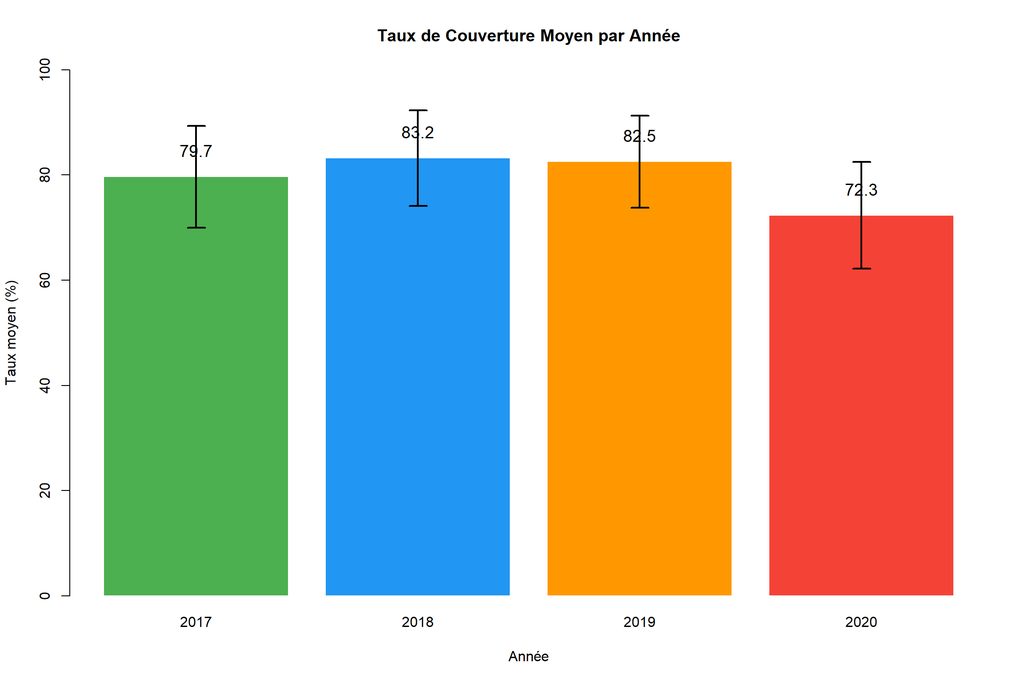

```r
# Graphique : Barplot des moyennes avec barres d'erreur
moyennes_plot <- data_clean %>%
  group_by(annee) %>%
  summarise(
    moyenne = mean(`taux_de_ couverture`, na.rm = TRUE),
    sd = sd(`taux_de_ couverture`, na.rm = TRUE),
    n = n()
  ) %>%
  mutate(se = sd / sqrt(n))

barplot_heights <- barplot(moyennes_plot$moyenne,
                           names.arg = moyennes_plot$annee,
                           ylim = c(0, 100),
                           col = c("#4CAF50", "#2196F3", "#FF9800", "#F44336"),
                           main = "Taux de Couverture Moyen par Année",
                           xlab = "Année",
                           ylab = "Taux moyen (%)",
                           border = "white")
arrows(x0 = barplot_heights,
       y0 = moyennes_plot$moyenne - moyennes_plot$se,
       x1 = barplot_heights,
       y1 = moyennes_plot$moyenne + moyennes_plot$se,
       angle = 90, code = 3, length = 0.1, lwd = 2)
text(barplot_heights, moyennes_plot$moyenne + 5,
     labels = round(moyennes_plot$moyenne, 1), cex = 1.2)
```

**Warning**

### 0.15 📈 Question 2 : Modèle de régression

**📝 Voir le code**

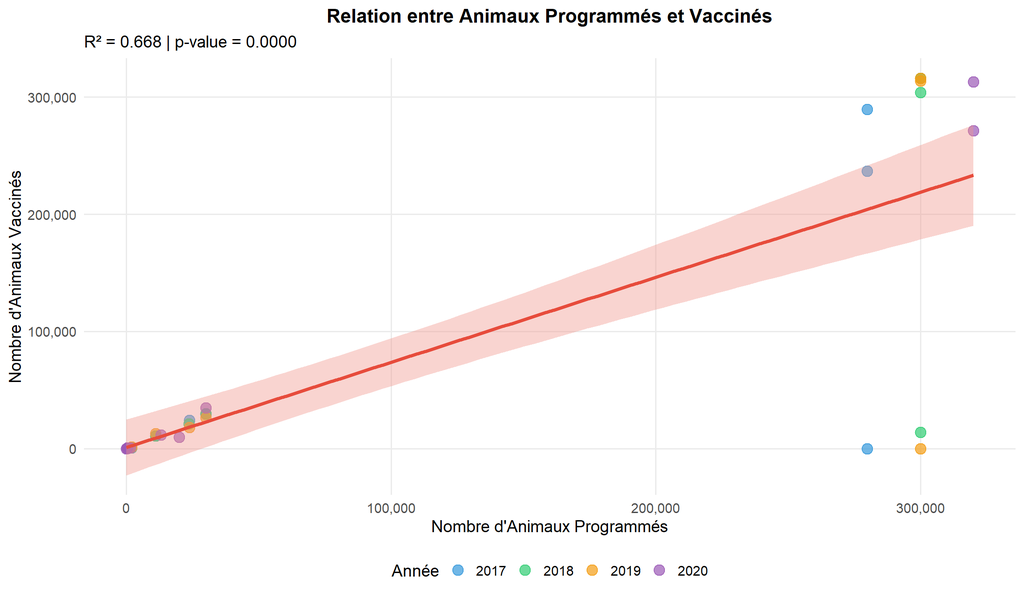

```r
# Modèle de régression linéaire
modele_reg <- lm(nombre_animaux_vaccines ~ nombre_animaux_programmes, data = data_clean)

# Graphique de régression
ggplot(data_clean, aes(x = nombre_animaux_programmes, y = nombre_animaux_vaccines)) +
  geom_point(aes(color = annee), size = 4, alpha = 0.7) +
  geom_smooth(method = "lm", formula = y ~ x,
              color = "#e74c3c",
              fill = "#f1948a",
              se = TRUE,
              linewidth = 1.5) +
  scale_color_manual(values = c("2017" = "#3498db",
                                 "2018" = "#2ecc71",
                                 "2019" = "#f39c12",
                                 "2020" = "#9b59b6")) +
  labs(
    title = "Relation entre Animaux Programmés et Vaccinés",
    subtitle = sprintf("R² = %.3f | p-value = %.4f",
                      summary(modele_reg)$r.squared,
                      summary(modele_reg)$coefficients[2, 4]),
    x = "Nombre d'Animaux Programmés",
    y = "Nombre d'Animaux Vaccinés",
    color = "Année"
  ) +
  theme_minimal(base_size = 14) +
  theme(
    plot.title = element_text(face = "bold", size = 16, hjust = 0.5),
    legend.position = "bottom",
    panel.grid.minor = element_blank()
  ) +
  scale_x_continuous(labels = comma) +
  scale_y_continuous(labels = comma)
```

**✅ Résultats du modèle :** Le modèle de régression explique 66.8% de la variance. Pour chaque animal supplémentaire programmé, on vaccine en moyenne 0.726 animaux.

🎯 CONCLUSION ET RECOMMANDATIONS

### 0.16 🏆 Principaux résultats

```
1. Performance globale : Taux moyen de 79.4 %
```

```
2. Meilleure année : 2018 (83.2%)
```

[output not shown]

[output not shown]

[output not shown]

### 0.17 📋 Recommandations stratégiques

```
1. 🔍 Cibler les espèces à faible taux de couverture
```

```
2. 📅 Optimiser la planification des campagnes
```

```
3. 📊 Renforcer le monitoring en temps réel
```

```
4. 🤝 Améliorer la coordination inter-année
```

```
5. 🎯 Établir des objectifs réalistes
```

### 0.18 🚀 Perspectives futures

- Intégration des données climatiques
- Analyse spatiale par délégation
- Modélisation prédictive
- Dashboard interactif de suivi

### 📊 PROJET TERMINÉ

**Analyse complétée avec succès** | *Meddeb Acharf - 2025*

Document généré le : 06 janvier 2026

R 4.3.1 tidyverse ggplot2 Quarto